# # SICSS Norrköping 2025: Network Analysis (SOLUTIONS)

## 2 Basic network descriptives

### 2.1 Macro level (global level):

Summary statistics, such as - size, and average degree, degree distribution - average clustering - transitivity

#### 2.1.1 Size and degrees

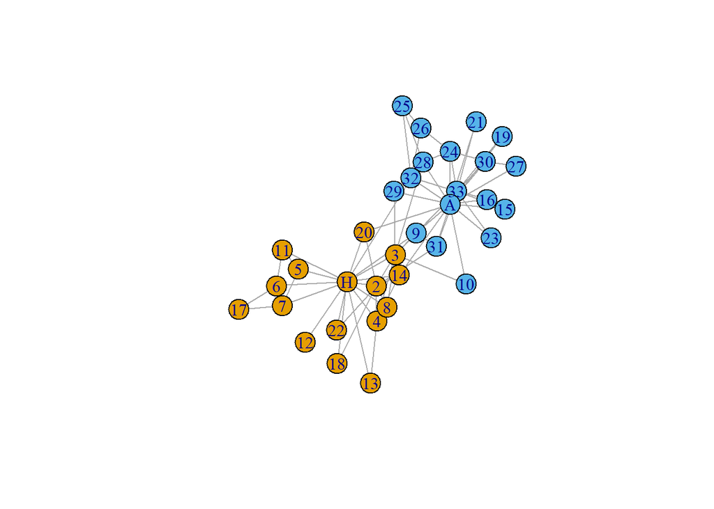

```r
data(karate) # data is loaded into a variable called karate

karate <- karate |>
  igraph::upgrade_graph() |>
  as_tbl_graph()#This graph was created by an old(er) igraph version.

plot(karate)
```

```r
# number of nodes
#V(karate)
vcount(karate)
```

```
[1] 34
```

```r
# number of edges
#E(karate)
ecount(karate)
```

```
[1] 78
```

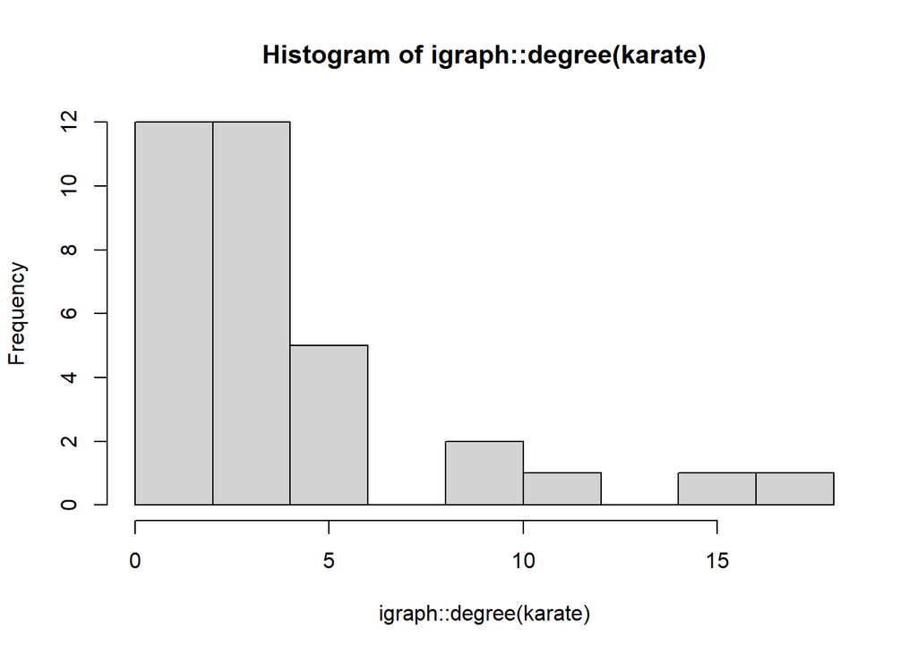

```r
# degrees
#igraph::degree(karate)

# degree distribution
hist(igraph::degree(karate))
```

#### 2.1.2 Transitivity and average clustering coefficient

Often also useful descriptives at the macro level is the transitivity coefficient and the average clustering coefficient (clustering coefficients also exist at the local (node-) level). Transitivity describes how many of the existing triads are actually closed. The average clustering coefficient describes – as the name already indicates – the average of all nodes’ clustering coefficient. The node-level clustering coefficient describes the fraction of possible triangles through a node that actually exists.

```r
adj_mtx_karate <- karate |>
  as_adjacency_matrix(sparse = igraph_opt("sparsematrices")) |>
  as.matrix() # convert igraph object to matrix (as sna package functions take matrices as input)

sna::isolates(adj_mtx_karate) # Check for isolates
```

```
integer(0)
```

```r
sna::gden(adj_mtx_karate) # Density (Number of actual ties over Number of potential ties)
```

```
[1] 0.1390374
```

```r
# grecip(adj_mtx_karate,measure='edgewise') # For directed graphs one can check for reciprocity (Number of mutual ties over Number of existing ties)

sna::gtrans(adj_mtx_karate, measure='weak') # Transitivity (how many of existing relationship are closed (triangles))
```

```
[1] 0.2556818
```

```r
sna::gtrans(adj_mtx_karate, measure='strong')
```

```
[1] 0.8465909
```

```r
# Dyadic and triadic configurations
sna::dyad.census(adj_mtx_karate) # number of ties that are mutual, asymmetric, do not exist
```

```
     Mut Asym Null
[1,]  78    0  483
```

```r
sna::triad.census(adj_mtx_karate) # see: https://i.stack.imgur.com/9Xo0R.png
```

```
      003 012  102 021D 021U 021C 111D 111U 030T 030C 201 120D 120U 120C 210
[1,] 3971   0 1575    0    0    0    0    0    0    0 393    0    0    0   0
     300
[1,]  45
```

### 2.2 Meso level (everything ‘in between’):

A group of nodes’ characteristics live at the mesoscale, such as - community detection - homophily - assortativity

#### 2.2.1 Community detection

Community detection is a very large field of research and has received a lot of attention in the past. The wish behind community detection basically is to identify a network’s mesoscale organisation. In simplistic terms, a community is a group of nodes which are somewhat more related to each other than to others in the network. Community detection for networks is conceptually similar to data clustering in machine learning. It is helpful if one wants to find nodes that would, for example, react similarly to an external stimulus or if you want to visualize the meso-level organisation of a network.

There are many different algorithms out there to find communities: Some use a group’s internal density, the similarity to neighbours, or the idea of random walks, … As some of the approaches out there differ in their internal logic, they might yield slightly different results.

IGRAPH has some community detection algorithms built-in, which you can find [here](https://networkx.org/documentation/stable/reference/algorithms/community.html), and which we will use in the following.

```r
# CLUSTERING ALGORITHMS

# GIRVAN-NEWMAN
# Partitioning is based on edge betweeness.
gn_clustering <- karate |>
  cluster_edge_betweenness(modularity=TRUE, membership=TRUE)
gn_clustering
```

```
IGRAPH clustering edge betweenness, groups: 6, mod: 0.35
+ groups:
  $`1`
  [1] "Mr Hi"    "Actor 2"  "Actor 4"  "Actor 8"  "Actor 12" "Actor 13"
  [7] "Actor 18" "Actor 20" "Actor 22"

  $`2`
  [1] "Actor 3"  "Actor 10" "Actor 14" "Actor 29"

  $`3`
  [1] "Actor 5"  "Actor 6"  "Actor 7"  "Actor 11" "Actor 17"

  + ... omitted several groups/vertices
```

```r
gn_clustering$modularity
```

```
 [1] -0.0511047394 -0.0465508517 -0.0294409775 -0.0128558310 -0.0007215007
 [6]  0.0181687000  0.0460073837  0.0582635258  0.0904031034  0.1027904275
[11]  0.1135848279  0.1203875490  0.1422668241  0.1576151122  0.1643897228
[16]  0.1765896441  0.1960045726  0.2127021608  0.2154569817  0.2289499822
[21]  0.2412998257  0.2627480744  0.2777402972  0.2908959727  0.3056539420
[26]  0.3154082570  0.3270272296  0.3366972133  0.3452990011  0.3266617942
[31]  0.3187252863  0.3145462042  0.3092895560  0.0000000000
```

```r
# Communities are identified as components in the edge-pruned graph
# The partitioning where the modularity is the highest is the one that gets chosen at the end.

# Add a node attribute for visual color based on the original 'Faction'.
# Faction is 1 or 2. We'll map this to 'gold' and 'steelblue'.
V(karate)$node_visual_color <- ifelse(V(karate)$Faction == 1, 'gold', 'steelblue')

# Add a unique node identifier, crucial for joining data later.
# Ensure it's character type for robust joins.
V(karate)$node_identifier <- as.character(1:vcount(karate))

# WALKTRAP
# The walk trap algorithm is based on a series of short random walks.
# Random walks are hypothesized to stay within the same community.
walk_clustering <- cluster_walktrap(karate, step=10)
walk_clustering
```

```
IGRAPH clustering walktrap, groups: 3, mod: 0.43
+ groups:
  $`1`
   [1] "Actor 9"  "Actor 10" "Actor 15" "Actor 16" "Actor 19" "Actor 21"
   [7] "Actor 23" "Actor 24" "Actor 25" "Actor 26" "Actor 27" "Actor 28"
  [13] "Actor 29" "Actor 30" "Actor 31" "Actor 32" "Actor 33" "John A"

  $`2`
   [1] "Mr Hi"    "Actor 2"  "Actor 3"  "Actor 4"  "Actor 8"  "Actor 12"
   [7] "Actor 13" "Actor 14" "Actor 18" "Actor 20" "Actor 22"

  $`3`
  + ... omitted several groups/vertices
```

```r
# MOODY-WHITE
blocks_clustering <- cohesive_blocks(karate)
blocks_clustering$blocks
```

```
[[1]]
+ 34/34 vertices, named, from 4b458a1:
 [1] Mr Hi    Actor 2  Actor 3  Actor 4  Actor 5  Actor 6  Actor 7  Actor 8
 [9] Actor 9  Actor 10 Actor 11 Actor 12 Actor 13 Actor 14 Actor 15 Actor 16
[17] Actor 17 Actor 18 Actor 19 Actor 20 Actor 21 Actor 22 Actor 23 Actor 24
[25] Actor 25 Actor 26 Actor 27 Actor 28 Actor 29 Actor 30 Actor 31 Actor 32
[33] Actor 33 John A

[[2]]
+ 28/34 vertices, named, from 4b458a1:
 [1] Mr Hi    Actor 2  Actor 3  Actor 4  Actor 8  Actor 9  Actor 10 Actor 13
 [9] Actor 14 Actor 15 Actor 16 Actor 18 Actor 19 Actor 20 Actor 21 Actor 22
[17] Actor 23 Actor 24 Actor 25 Actor 26 Actor 27 Actor 28 Actor 29 Actor 30
[25] Actor 31 Actor 32 Actor 33 John A

[[3]]
+ 6/34 vertices, named, from 4b458a1:
[1] Mr Hi    Actor 5  Actor 6  Actor 7  Actor 11 Actor 17

[[4]]
+ 5/34 vertices, named, from 4b458a1:
[1] Mr Hi   Actor 2 Actor 3 Actor 4 Actor 8

[[5]]
+ 7/34 vertices, named, from 4b458a1:
[1] Mr Hi    Actor 2  Actor 3  Actor 9  Actor 31 Actor 33 John A

[[6]]
+ 5/34 vertices, named, from 4b458a1:
[1] Mr Hi    Actor 5  Actor 6  Actor 7  Actor 11

[[7]]
+ 5/34 vertices, named, from 4b458a1:
[1] Mr Hi    Actor 2  Actor 3  Actor 4  Actor 14

[[8]]
+ 10/34 vertices, named, from 4b458a1:
 [1] Actor 3  Actor 24 Actor 25 Actor 26 Actor 28 Actor 29 Actor 30 Actor 32
 [9] Actor 33 John A
```

```r
# Other clustering algorithms that you could use:
cluster_louvain(karate)
```

```
IGRAPH clustering multi level, groups: 4, mod: 0.44
+ groups:
  $`1`
   [1] "Mr Hi"    "Actor 2"  "Actor 3"  "Actor 4"  "Actor 8"  "Actor 12"
   [7] "Actor 13" "Actor 14" "Actor 18" "Actor 20" "Actor 22"

  $`2`
  [1] "Actor 5"  "Actor 6"  "Actor 7"  "Actor 11" "Actor 17"

  $`3`
   [1] "Actor 9"  "Actor 10" "Actor 15" "Actor 16" "Actor 19" "Actor 21"
   [7] "Actor 23" "Actor 27" "Actor 30" "Actor 31" "Actor 33" "John A"
  + ... omitted several groups/vertices
```

```r
cluster_fast_greedy(karate)
```

```
IGRAPH clustering fast greedy, groups: 3, mod: 0.43
+ groups:
  $`1`
   [1] "Actor 9"  "Actor 10" "Actor 15" "Actor 16" "Actor 19" "Actor 21"
   [7] "Actor 23" "Actor 24" "Actor 25" "Actor 26" "Actor 27" "Actor 28"
  [13] "Actor 29" "Actor 30" "Actor 31" "Actor 32" "Actor 33" "John A"

  $`2`
   [1] "Mr Hi"    "Actor 2"  "Actor 3"  "Actor 4"  "Actor 8"  "Actor 12"
   [7] "Actor 13" "Actor 14" "Actor 18" "Actor 20" "Actor 22"

  $`3`
  + ... omitted several groups/vertices
```

```r
cluster_leading_eigen(karate)
```

```
IGRAPH clustering leading eigenvector, groups: 5, mod: 0.44
+ groups:
  $`1`
   [1] "Mr Hi"    "Actor 2"  "Actor 3"  "Actor 4"  "Actor 8"  "Actor 13"
   [7] "Actor 14" "Actor 18" "Actor 20" "Actor 22"

  $`2`
   [1] "Actor 9"  "Actor 10" "Actor 15" "Actor 16" "Actor 19" "Actor 21"
   [7] "Actor 23" "Actor 27" "Actor 30" "Actor 31" "Actor 33" "John A"

  $`3`
  [1] "Actor 5"  "Actor 6"  "Actor 7"  "Actor 11" "Actor 17"
  + ... omitted several groups/vertices
```

```r
#?cluster_leading_eigen

# How to extract the grouping
gn_clustering$membership
```

```
 [1] 1 1 2 1 3 3 3 1 4 2 3 1 1 2 4 4 3 1 4 1 4 1 4 5 5 5 6 5 2 6 4 4 4 4
```

```r
karate |>
  activate(nodes) |>
  mutate(gn_group = as.factor(gn_clustering$membership),
         wt_group = as.factor(walk_clustering$membership),
         fg_group = as.factor(cluster_fast_greedy(karate)$membership),
         lu_group = as.factor(cluster_louvain(karate)$membership),
         le_group = as.factor(cluster_leading_eigen(karate)$membership)) -> karate

V(karate)$fg_group
```

```
 [1] 2 2 2 2 3 3 3 2 1 1 3 2 2 2 1 1 3 2 1 2 1 2 1 1 1 1 1 1 1 1 1 1 1 1
Levels: 1 2 3
```

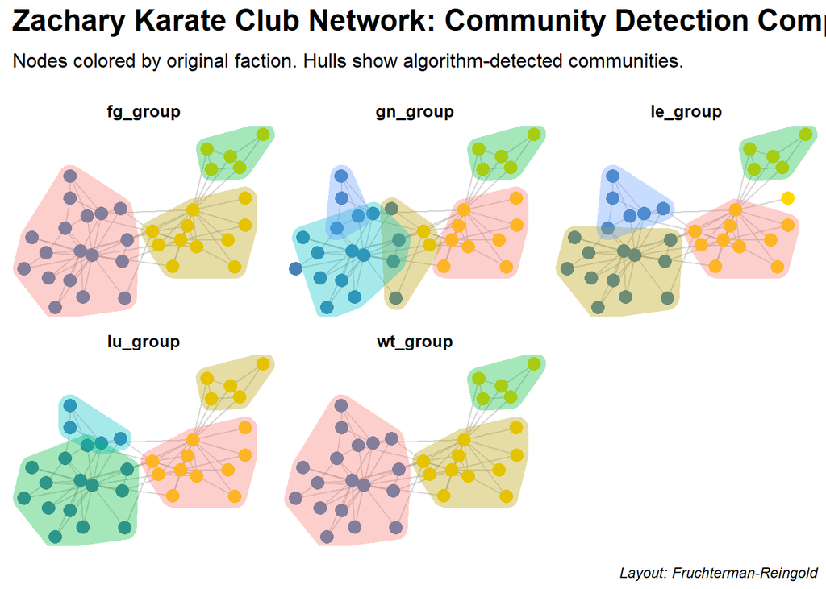

```r
# Add clustering to the visualisation
set.seed(42)
set_layout <- create_layout(karate, layout = 'fr')

set_layout |>
  pivot_longer(
    cols = c(gn_group, wt_group, fg_group, lu_group, le_group), # Columns to pivot
    names_to = "algorithm",                 # New column for algorithm names
    values_to = "cluster_membership_id"     # New column for cluster IDs for that algorithm
  ) ->pivoted_plotting_data


set_layout |>
  ggraph()+
  geom_edge_link(alpha = 0.4, colour = 'grey60') + # Slightly darker grey for better visibility
  # Draw nodes (common to all facets)
  # Node color is from 'node_visual_color' (gold/steelblue based on Faction)
  # This aes() is evaluated against graph_layout_with_all_attrs
  geom_node_point(aes(colour = node_visual_color), size = 3.5, show.legend = FALSE) +
  scale_colour_identity() + # Because node_visual_color directly specifies the colors

  # Draw community hulls using ggforce::geom_mark_hull
  # This layer uses 'pivoted_plotting_data', which is already faceted by 'algorithm'.
  # The aes() here is evaluated against pivoted_plotting_data.
  geom_mark_hull(
    data = pivoted_plotting_data,
    aes(x = x, y = y,
        group = cluster_membership_id,
        fill = cluster_membership_id),
    colour = NA, # No border for the hull polygons
    alpha = 0.35, # Hull transparency
    concavity = 4, # Adjust concavity
    expand = unit(2.5, 'mm'), # Padding around groups
    show.legend = FALSE # No legend for hull fill colors (cluster IDs)
  )+
  facet_wrap(~algorithm, ncol = 3) +# Arrange in a grid, adjust ncol as needed
  labs(
    title = "Zachary Karate Club Network: Community Detection Comparison",
    subtitle = "Nodes colored by original faction. Hulls show algorithm-detected communities.",
    caption = "Layout: Fruchterman-Reingold"
  ) +
  theme_graph(
    base_family = 'sans', # Clean font
    strip_text_size = 10, # Size for facet titles (algorithm names)
    plot_margin = margin(5, 5, 5, 5) # Add some margin around the plot
  )
```

**What did you observe?**

There are different ways to continue from this finding: One option is to evaluate the partitioning based on some quality measure (e.g. the “modularity score”, or the “Normalised Mutual Information”). Another option would be to apply “[consensus clustering](https://www.nature.com/articles/srep00336)” – an approach inspired by an observation from machine learning which can be summarised as ‘averaging several simple models often yields better accuracy than constructing the most sophisticated model possible’. The idea is very simple: Run several clustering algorithms (also the same one many times) and average the results. However, this method should not be applied blindly: Make sure the results you are averaging stem from an internally consistent ensemble of clustering algorithms (i.e. the same “family”, meaning: all algorithms apply the same logic. For example, don’t mix flow-based (infomap and co) with density optimization algorithms, etc.).

#### 2.2.2 Quantifying homophily: Assortativity coefficient

At the meso-level, we could also be interested in quantifying the extent to which homophily is driving a network’s connections. This is where the assortativity coefficient can help us. The idea behind this measure is a comparison of the number of ties that occur in-goup vs such that bridge to another group compared to the total number of ties. The assortativity coefficient, however, is a bit more advanced than this simple illustration: It is able to take different group sizes/more than two groups into account. For the assortativity coefficient, 1 means perfect assortativity (assortativity: more in-group than between group ties), -1 means perfect disassortativity (disassortativity: more between group than in-group ties).

```r
# Assortativity (for continuous (quantitative) attributes)
assortativity_degree(karate,directed=FALSE) # degree assortativity (Finding: high degree nodes tend to connect to low degree nodes)
```

```
[1] -0.4756131
```

```r
# Assortativity for qualitative attributes
assortativity(karate, values = V(karate)$color, directed=FALSE)
```

```
[1] 0.7434211
```

Here we find the Karate network to be assorted by ‘support’ meaning that there is not to much mixing among support groups.

### 2.3 Micro level (local level):

Node level characteristics such as - centrality measures (degree centrality, betweenness centrality, closeness centrality, pagerank) - nodes’ degrees

On the micro-level, we are usually interested in the question: Which are the important nodes? In which way are they important?

To answer this question, we could start looking at the degree of a node, assuming that the ones with the most links are most likely the most important ones. But what if we want to measure another “type of importance”, e.g. if a node has a bridging functionality (critical for example, for information flow, exchange, exposure, etc.)? Such a node probably has a very small degree, but if it were gone, the topology of the network would be substantially different.

To capture these different qualities, we have different measures at hand (usually summarised as centrality measures). The most important ones are closeness centrality, betweenness centrality, and PageRank, and the local clustering coefficients. IGRAPH and SNA have the most important algorithms readily implemented.

```r
# Centrality measures
degree(karate) # degree
```

```
   Mr Hi  Actor 2  Actor 3  Actor 4  Actor 5  Actor 6  Actor 7  Actor 8
      16        9       10        6        3        4        4        4
 Actor 9 Actor 10 Actor 11 Actor 12 Actor 13 Actor 14 Actor 15 Actor 16
       5        2        3        1        2        5        2        2
Actor 17 Actor 18 Actor 19 Actor 20 Actor 21 Actor 22 Actor 23 Actor 24
       2        2        2        3        2        2        2        5
Actor 25 Actor 26 Actor 27 Actor 28 Actor 29 Actor 30 Actor 31 Actor 32
       3        3        2        4        3        4        4        6
Actor 33   John A
      12       17
```

```r
betweenness(karate) # betweenness centrality
```

```
     Mr Hi    Actor 2    Actor 3    Actor 4    Actor 5    Actor 6    Actor 7
250.150000  33.800000  36.650000   1.333333   0.500000  15.500000  15.500000
   Actor 8    Actor 9   Actor 10   Actor 11   Actor 12   Actor 13   Actor 14
  0.000000  13.100000   7.283333   0.500000   0.000000   0.000000   1.200000
  Actor 15   Actor 16   Actor 17   Actor 18   Actor 19   Actor 20   Actor 21
  0.000000   0.000000   0.000000  16.100000   3.000000 127.066667   0.000000
  Actor 22   Actor 23   Actor 24   Actor 25   Actor 26   Actor 27   Actor 28
  0.000000   0.000000   1.000000  33.833333   0.500000   0.000000   6.500000
  Actor 29   Actor 30   Actor 31   Actor 32   Actor 33     John A
 10.100000   0.000000   3.000000  66.333333  38.133333 209.500000
```

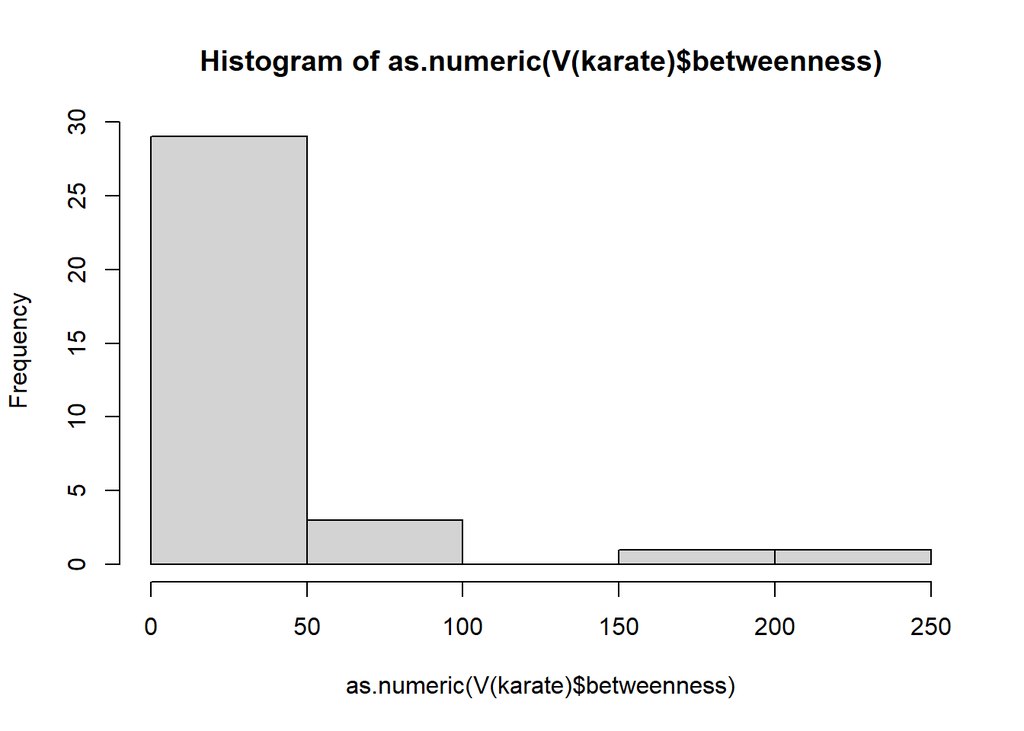

```r
#closeness(karate) # closeness centrality
#page_rank(karate)$vector # pagerank
#transitivity(karate, type = "local") # local clustering coefficient

# Assign centrality score as attribute, example here is betweenness centrality
karate |> activate(nodes) |>
  mutate(degree = centrality_degree(),
         betweenness = centrality_betweenness(),
         closeness = centrality_closeness(),
         pagerank = centrality_pagerank()) -> karate


# Visualisation
hist(V(karate)$betweenness |> as.numeric())
```

[figure not shown]

```r
# Normalise values to get a ranking
normalize <- function(x){(x-min(x))/(max(x)-min(x))} # min-max scaling brings everything to the interval [0,1]

karate |>
  activate(nodes) |>
  mutate(
    betweenness_index = ((betweenness |> normalize()) * 9 |> round() + 1),
    closeness_index = ((closeness |> normalize()) * 9 |> round() + 1),
    degree_index = ((degree |> normalize()) * 9 |> round() + 1),
    pagerank_index = ((pagerank |> normalize()) * 9 |> round() + 1)

  ) -> karate

set.seed(42)
karate |>
  create_layout(layout = 'fr') -> set_layout

p1 <- karate |>
ggraph(layout = set_layout)+
  geom_edge_link(color = "gray") +
  geom_node_point(aes(color = betweenness_index), size = 10)+
  scale_color_gradient(low = "lightblue", high = "darkblue",
                       name  = "Index") +
  theme_void()+
  labs(title = "Degree centrality")
p2 <- karate |>
  ggraph(layout = set_layout)+
  geom_edge_link(color = "gray") +
  geom_node_point(aes(color = betweenness_index), size = 10) +
  scale_color_gradient(low = "lightblue", high = "darkblue",
                       name  = "Index") +
  theme_void()+
  labs(title = "Betweenness centrality")
p3 <- karate |>
  ggraph(layout = set_layout)+
  geom_edge_link() +
  geom_node_point(aes(color = closeness_index), size = 10) +
  scale_color_gradient(low = "lightblue", high = "darkblue",
                       name  = "Index") +
  theme_void()+
  labs(title = "Closeness centrality")
p4 <- karate |>
  ggraph(layout = set_layout)+
  geom_edge_link() +
  geom_node_point(aes(color = pagerank_index), size = 10) +
  scale_color_gradient(low = "lightblue", high = "darkblue",
                       name  = "Index") +
  theme_void()+
  labs(title = "Pagerank centrality")
p1 + p2 + p3 + p4 + plot_layout(guides='collect') &
  theme(legend.position='bottom')
```

## 3 Network thinking

This section aims at stimulating your network thinking. You will discover two network peculiarities that might appear counterintuitive at first glance, but make a lot of sense once you take the networks’ topologies into consideration.

### 3.1 Majority illusion

In networks where we observe strong homophily, it might happen that we observe something like the “illusion of a majority”: Even if the majority does not hold a certain characteristic, we can draw a network in which most people believe the opposite is true.

Let’s look at an easy example. We can use our simple friendship network from above, which is in the variable `g_undirected`. In this network, nodes represent friends who are assigned one attribute (their gender).

To test for the majority illusion, we need to compare the average of the gender shares in all ego networks to the global gender share. Hence, we first have to iterate over all ego networks (one network per friend), remove the ego node for each ego network, and calculate the share of female friends a person “sees” in their ego network. Then, we need to average the perceived gender share among all nodes. In a second step, we need to calculate the gender shares in the friendship network from a global perspective.

Let’s extract an ego network for one person, for example, Amaya

```r
mtx_friends <- g_undirected |>
  as_adjacency_matrix(
    sparse = igraph_opt("sparsematrices")) |>
  as.matrix()

genders <- V(g_undirected)$gender
names <- V(g_undirected)$name

ego_networks <- sna::ego.extract(mtx_friends, ego = NULL, neighborhood = c("combined"))
friends_of_ego <- colnames(ego_networks$Amaya)[colnames(ego_networks$Amaya) != "Amaya"]

# get gender shares in ego network
g_undirected |>
  igraph::delete_vertices(!V(g_undirected)$name %in% friends_of_ego) |>
  vertex_attr("gender") |>
  table() |>
  prop.table()
```

```
   d    f    m
0.25 0.50 0.25
```

```r
# calculation of gender shares in terms of local averages
avg_f_gender = 0
avg_d_gender = 0
avg_m_gender = 0

genders <- V(g_undirected)$gender
names <- V(g_undirected)$name

mtx_friends <- g_undirected |>
  as_adjacency_matrix(sparse = igraph_opt("sparsematrices")) |>
                        as.matrix()
ego_networks <- sna::ego.extract(mtx_friends, ego = NULL, neighborhood = c("combined"))

for (ego_node in V(g_undirected)$name) {

  idx <- which(names == ego_node)
  friends_of_ego <- colnames(ego_networks[[idx]])[colnames(ego_networks[[idx]]) != ego_node]

  # get gender shares in ego network
  proportions = prop.table(table(V(g_undirected)$gender[which(V(g_undirected)$name %in% friends_of_ego)]))

  if (is.na(as.table(proportions)["d"]) == FALSE) {
    avg_d_gender <- avg_d_gender + as.table(proportions)[["d"]]
  }

  if (is.na(as.table(proportions)["f"]) == FALSE) {
    avg_f_gender <- avg_f_gender + as.table(proportions)[["f"]]
  }

  if (is.na(as.table(proportions)["m"]) == FALSE) {
    avg_m_gender <- avg_m_gender + as.table(proportions)[["m"]]
  }
}

# Extract results
cat(paste("The average node thinks that", round(100 * avg_f_gender / length(names)), "% of the network is female,",
          round(100 * avg_d_gender / length(names)), "% diverse, and",
          round(100 * avg_m_gender / length(names)), "% male."))
```

```
The average node thinks that 68 % of the network is female, 7 % diverse, and 25 % male.
```

```r
# calculation of the gender shares from a global perspective
global_absolut_f = 0
global_absolut_d = 0
global_absolut_m = 0

for (node in V(g_undirected)$name) { # Iterate over all nodes
  if (V(g_undirected)[node]$gender == "f") { # Count the number of female friends
      global_absolut_f <- global_absolut_f + 1
      }
  if (V(g_undirected)[node]$gender == "d") {  # Count the number of divers friends
      global_absolut_d <- global_absolut_d + 1
      }
  if (V(g_undirected)[node]$gender == "m") {  # Count the number of male friends
      global_absolut_m <- global_absolut_m + 1
      }
  }


# Extract results
cat(paste("From a global perspective,", round(100 * global_absolut_f / length(names)), "% of the network is female,",
          round(100 * global_absolut_d / length(names)), "% diverse, and",
          round(100 * global_absolut_m / length(names)), "% male."))
```

```
From a global perspective, 43 % of the network is female, 14 % diverse, and 43 % male.
```

#### 3.1.1 Exercise 1:

What do you observe? Why do you see what you see?

YOUR COMMENTS HERE

#### 3.1.2 Exercise 2 (Extra): Reflections on the majority illusion

1. Which implications does this phenomenon, in your opinion, have for social cohesion? Or the “public opinion”? Political influence? …?
2. The majority illusion is only one peculiarity. Another stunning case, driven by homophily, that I want to bring to your attention is that even mild preferences often result in very strict homophilic patterns (along the lines of “the aggregate is more than the sum (of individual-level preferences)”). One of the most famous examples to illustrate this segregation (see work of Nobel Prize-winning game theorist Thomas Schelling, and especially his paper [Dynamic models of segregation](https://www.stat.berkeley.edu/~aldous/157/Papers/Schelling_Seg_Models.pdf) from 1971). You can play an interactive version of the paper content here: [Parable of Polygons](https://ncase.me/polygons/). Even if people are happy being in the minority, the group ends up being segregated. Comment: There is no network in this interactive post, but one could easily transfer this to a friendship network where people are allowed to rewire their connections.

YOUR COMMENTS HERE

#### 3.1.3 Exercise 3: Blog posts

For this exercise, we will use some (a bit more exiting) real-world data. Precisely, the dataset from this [article](https://dl.acm.org/doi/pdf/10.1145/1134271.1134277?casa_token=4s9yFKDhE2oAAAAA:8k4b1uqozQwxn4DBIg0lDn9v0DnP07KxgYMyPYRtvmlwdf3i-8yMfpd41C74GAkFuGiRRKb9OYSuxw). The dataset contains front-page hyperlinks (edges) between blogs (nodes) in the context of the 2004 US election (directed network). The dataset is available [here](http://konect.cc/networks/moreno_blogs/).

1. Load the data (edges stored in `edges_blogs.txt`) and assign the labels (stored in `node_labels_blogs.txt`) to every node.
2. Repeat the steps as in Exercise 1. Do you find a majority illusion here, too?

```r
df1_graph <- read.table(
  here("data", "edges_blogs.txt"),
  sep="\t",
  header=FALSE)
df2_nodes_attributes <- read.table(
  here("data", "node_labels_blogs.txt"),
  sep="\t",
  header=FALSE)

colnames(df1_graph) <- c("node1", "node2")
colnames(df2_nodes_attributes) <- c("node", "attribute")


g_blogs <- graph_from_data_frame(df1_graph, directed=FALSE)
g_blogs <- set_vertex_attr(g_blogs, "leaning", index = V(g_blogs),
                           df2_nodes_attributes$attribute)
ecount(g_blogs)
```

```
[1] 16715
```

```r
vcount(g_blogs)
```

```
[1] 1224
```

```r
edge_density(g_blogs)
```

```
[1] 0.02233205
```

```r
transitivity(g_blogs)
```

```
[1] 0.2259585
```

```r
is_directed(g_blogs)
```

```
[1] FALSE
```

```r
node_names <- V(g_blogs)$name

avg_right_leaning_tidy <- node_names |>
  purrr::map_dbl(function(current_ego_name) {
    # 1. Get the names of the alters (neighbors) for the current_ego_name
    alter_node_names <- names(neighbors(g_blogs, current_ego_name))

    # If the ego node has no alters, its contribution to the sum is 0
    if (length(alter_node_names) == 0) {
      return(0.0)
    }

    # 2. Filter 'df2_nodes_attributes' for these alters and get their attributes.
    #    We also filter out NA attributes to match the default behavior of `table()`.
    alters_attributes_df <- df2_nodes_attributes |>
      filter(as.character(node) %in% alter_node_names) |>
      filter(!is.na(attribute)) # Exclude rows where the attribute itself is NA

    # If no alters are found in the attributes dataframe or all their attributes are NA, contribution is 0
    if (nrow(alters_attributes_df) == 0) {
      return(0.0)
    }

    # 3. Calculate the proportions of each attribute among the alters
    proportions_summary <- alters_attributes_df |>
      count(attribute, name = "n_val") |>          # Count occurrences of each attribute
      mutate(proportion = n_val / sum(n_val))   # Calculate proportion for each attribute

    # 4. Extract the proportion for the "right-leaning" attribute
    right_leaning_prop_value <- proportions_summary |>
      filter(attribute == "right-leaning") |>
      pull(proportion)                            # Extract the proportion value

    # If "right-leaning" attribute was not found among alters, its proportion is 0
    if (length(right_leaning_prop_value) == 0) {
      return(0.0)
    } else {
      # pull() might return multiple values if 'attribute' wasn't unique after count (not the case here)
      # We take the first (and should be only) value.
      return(right_leaning_prop_value[1])
    }
  }) |>
  sum(na.rm = TRUE)

# Extract results
cat(paste("The average node thinks that", round(100 * avg_right_leaning_tidy / vcount(g_blogs), 2), "% of the network is right-leaning."))
```

```
The average node thinks that 53.61 % of the network is right-leaning.
```

```r
# global perspective
prop.table(table(V(g_blogs)$leaning))
```

```
 left-leaning right-leaning
    0.4803922     0.5196078
```

```r
cat(paste("From a global perspective,", round(prop.table(table(V(g_blogs)$leaning))[["right-leaning"]]*100, 2), "% of the nodes are right-leaning."))
```

```
From a global perspective, 51.96 % of the nodes are right-leaning.
```

Even though both political blog communities are divided, the majority illusion does not seem to be present in this case. Both the averaged ego perspective and the global network perspective lead to similar results with respect to the share of nodes that are right-leaning.

### 3.2 The friendship paradox

#### 3.2.1 Exercise 4:

It’s time for the next peculiarity of network effects: The friendship paradox.

For this exercise, we will use the data from the following [paper](https://dl.acm.org/doi/pdf/10.1145/1592665.1592675): Viswanath, B., Mislove, A., Cha, M., & Gummadi, K. P. (2009). On the evolution of user interaction in Facebook. Proceedings of the 2nd ACM Workshop on Online Social Networks, 37–42.

You can find it in the data folder under the name `data-facebook.txt`.

```r
df2_graph <- read.table(
                        here("data", "data_facebook.txt"),
                        sep=" ", header=FALSE)
colnames(df2_graph) <- c("node1", "node2")

g_facebook <- graph_from_data_frame(
  df2_graph, directed=FALSE) |>
  as_tbl_graph()

vcount(g_facebook)
```

```
[1] 63731
```

```r
ecount(g_facebook)
```

```
[1] 817035
```

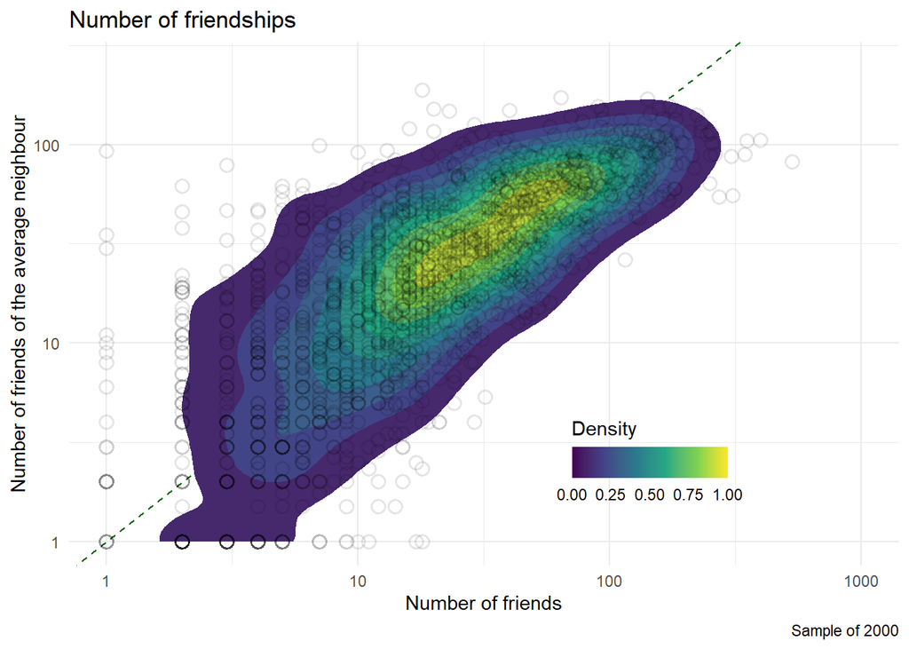

```r
# Get the degrees of the nodes
g_facebook |>
  activate(nodes) |>
  mutate(degree = centrality_degree()) -> g_facebook

neighbors_df <- g_facebook |>
  activate(edges) |>
  mutate(ego_degree = .N()$degree[from],
         alter_degree = .N()$degree[to])

neighbors_df |>
  as_tibble() |>
  rename(ego = from,
         alters = to,
         ego_degree = ego_degree,
         alter_degree = alter_degree) -> merged_df

# calculate how many friends and ego's friends have on average
avg_friends_df <- merged_df |>
  group_by(ego) |>
  summarise(ego_degree = min(ego_degree),
            avg_degree_neighbor = mean(alter_degree)) |>
  na.omit()

# Plot the data
avg_friends_df |>
  slice_sample(n = 2000) |>
  ggplot(aes(x = ego_degree, y = avg_degree_neighbor)) +
  geom_abline(slope = 1,
              intercept = 0, color = "darkgreen", linetype = "dashed") +
    stat_density_2d(aes(fill = after_stat(level)), geom = "polygon", alpha = 1)+
  geom_point(fill = NA, size = 3, alpha = 0.1, color = "black",
             shape = 21, stroke = 1) +
  scale_x_log10(limits = c(1, 1000)) +
  scale_y_log10(limits = c(1, 250)) +
  labs(x = "Number of friends",
       y = "Number of friends of the average neighbour",
       title = "Number of friendships",
      caption  = "Sample of 2000") +
  theme_minimal()+
  scale_fill_continuous(
    limits = c(0,1),
    breaks = c(0, 0.25, 0.5, 0.75, 1),
    type = "viridis",
    name = "Density",
    guide = guide_colourbar(direction = "horizontal")
    )+
  theme(legend.position = c(0.7, 0.2),
        legend.title.position = "top",
        legend.ticks = element_blank())
```

```r
# Count the number of nodes above and below the identity line
paradox_df <- merged_df |>
  group_by(ego) |>
  summarise(avg_degree_neighbor = mean(alter_degree),
            ego_degree = mean(ego_degree))

paradox_df <- paradox_df |>
  mutate(ego_more_than_alters = if_else(ego_degree > avg_degree_neighbor, "yes", "no"))

proportions <- prop.table(table(paradox_df$ego_more_than_alters))

# Check for the friendship paradox
if (proportions["no"] > proportions["yes"]) {
  print("We found a friendship paradox.")
} else {
  print("We did not observe a friendship paradox.")
}
```

```
[1] "We found a friendship paradox."
```

The friendship paradox is the observation that the degrees of the neighbours of a node in a network are, on average, greater than the degree of the node itself. In other words, your friends have more friends than you do. We see evidence for this in the data: if there was no degree assortativity in the network, points in the plot would scatter around the identity line. Instead, most points in the low and intermediate-range (people having one to around 80 friends) tend to be connected to individuals who have more friends. The most popular individuals in the network (100 friends and more) tend to be connected to individuals who have fewer friends, in other words, they have many ‘followers’ who are not so well connected.